# Machine Learning Course Project

Alexandra Kilmon

12/27/2019

## Introduction

One thing that people regularly do is quantify how much of a particular activity they do, but they rarely quantify how well they do it. In this project, data from accelerometers on the belt, forearm, arm, and dumbell of 6 participants will be analyzed to develop a machine learning algorithm to predict how well participants perform.

## Data Processing

This data set includes records from 6 males aged between 20-28 years, with little weight lifting experience. The “classe” variable defines how a participant performed a repetition of the Unilateral Dumbbell Biceps Curl:

- A: Exactly according to specification
- B: Throwing the elbows to the front
- C: Lifting the dumbbell only halfway
- D: Lowering the dumbbell only halfway
- E: Throwing the hips to the front

A training and testing data set was provided. Cross validation was used to subsample, without replacement, the training data set. 75% was used for the training set and 25% was used for the test data set. Once our model was fitted with the training data set, it was tested on the test data set pulled from the original training data set. Once further refinement was implemented, the model was tested on the original testing data set.

See the bar chart below to review a summary of the training data set.

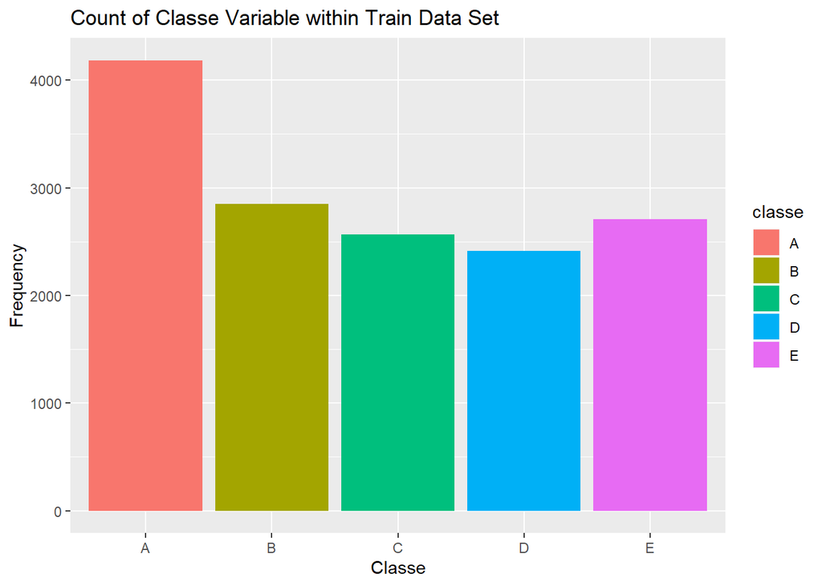

## Prediction Model 1: Decision Trees

[figure not shown]

```r
model1 <- rpart(classe ~ ., data=training, method="class")
fancyRpartPlot(model1)
```

```r
model1predict <- predict(model1, testing, type = "class")
model1confusmatrix <- confusionMatrix(model1predict, testing$classe)
model1confusmatrix
```

```
## Confusion Matrix and Statistics
##
##           Reference
## Prediction    A    B    C    D    E
##          A 1304  185   31  102   45
##          B   28  479   34   16   29
##          C   25  125  689  130  109
##          D   18   69   37  477   50
##          E   20   91   64   79  668
##
## Overall Statistics
##
##                Accuracy : 0.7376
##                  95% CI : (0.725, 0.7498)
##     No Information Rate : 0.2845
##     P-Value [Acc > NIR] : < 2.2e-16
##
##                   Kappa : 0.6659
##
##  Mcnemar's Test P-Value : < 2.2e-16
##
## Statistics by Class:
##
##                      Class: A Class: B Class: C Class: D Class: E
## Sensitivity            0.9348  0.50474   0.8058  0.59328   0.7414
## Specificity            0.8966  0.97295   0.9039  0.95756   0.9365
## Pos Pred Value         0.7822  0.81741   0.6391  0.73272   0.7245
## Neg Pred Value         0.9719  0.89115   0.9566  0.92311   0.9415
## Prevalence             0.2845  0.19352   0.1743  0.16395   0.1837
## Detection Rate         0.2659  0.09768   0.1405  0.09727   0.1362
## Detection Prevalence   0.3399  0.11949   0.2198  0.13275   0.1880
## Balanced Accuracy      0.9157  0.73884   0.8549  0.77542   0.8390
```

## Prediction Model 2: Random Forests

```r
controlRF <- trainControl(method="cv", number=3, verboseIter=FALSE)
model2 <- train(classe ~ ., data=training, method="rf", trControl=controlRF)
model2$finalModel
```

```
##
## Call:
##  randomForest(x = x, y = y, mtry = param$mtry)
##                Type of random forest: classification
##                      Number of trees: 500
## No. of variables tried at each split: 2
##
##         OOB estimate of  error rate: 0.69%
## Confusion matrix:
##      A    B    C    D    E  class.error
## A 4182    2    0    0    1 0.0007168459
## B   11 2828    9    0    0 0.0070224719
## C    0   16 2549    2    0 0.0070120764
## D    0    0   48 2362    2 0.0207296849
## E    0    0    2    8 2696 0.0036954915
```

```r
model2predict <- predict(model2, newdata=testing)
model2confusmatrix <- confusionMatrix(model2predict, testing$classe)
model2confusmatrix
```

```
## Confusion Matrix and Statistics
##
##           Reference
## Prediction    A    B    C    D    E
##          A 1395    1    0    0    0
##          B    0  946    8    0    0
##          C    0    2  847   14    0
##          D    0    0    0  790    2
##          E    0    0    0    0  899
##
## Overall Statistics
##
##                Accuracy : 0.9945
##                  95% CI : (0.992, 0.9964)
##     No Information Rate : 0.2845
##     P-Value [Acc > NIR] : < 2.2e-16
##
##                   Kappa : 0.993
##
##  Mcnemar's Test P-Value : NA
##
## Statistics by Class:
##
##                      Class: A Class: B Class: C Class: D Class: E
## Sensitivity            1.0000   0.9968   0.9906   0.9826   0.9978
## Specificity            0.9997   0.9980   0.9960   0.9995   1.0000
## Pos Pred Value         0.9993   0.9916   0.9815   0.9975   1.0000
## Neg Pred Value         1.0000   0.9992   0.9980   0.9966   0.9995
## Prevalence             0.2845   0.1935   0.1743   0.1639   0.1837
## Detection Rate         0.2845   0.1929   0.1727   0.1611   0.1833
## Detection Prevalence   0.2847   0.1945   0.1760   0.1615   0.1833
## Balanced Accuracy      0.9999   0.9974   0.9933   0.9910   0.9989
```

## Conclusions

```r
finalprediction <- predict(model2,testdataset)
finalprediction
```

```
##  [1] B A B A A E D B A A B C B A E E A B B B
## Levels: A B C D E
```

```r
writefiles = function(x){
  n = length(x)
  for(i in 1:n){
    filename = paste0("problem_id_",i,".txt")
    write.table(x[i], file = filename, quote = FALSE, row.names = FALSE, col.names = FALSE)
  }
}
writefiles(finalprediction)
```